# Project: Investigation of a Stroop Effect Task

- Variables
- Hypotheses
- Descriptive Statistics
- Data Visualizations
- Statistical Test Results
- Conclusions

## What are the Independent and Dependent variables?

**Independent Variable**: The colors of the words used in the experiment.  
**Dependent Variable**: The time it takes to name the color of the inks used in a given list. (Reaction Time)

## What are our hypotheses for this task? What kind of statistical test should we run?

**Null Hypothesis** - The changing of the colors of ink used for the words given to the subjects did not change the reaction times.  
H<sub>0</sub>:$ \mu d = 0 $  
**Alternative hypothesis** - The changing of the colors of ink increases or decreases the subjects’ reaction times.  
H<sub>0</sub>:$ \mu d \neq 0 $

#### Please note that $ \mu d $ will represent the difference in reaction times.

The type of test I will perform is a two-tailed dependent T-test. The reasoning for this is because our alternative hypothesis is looking to see if there is a difference at all in the times recorded from the Stroop Task. We are not looking to see if they are above or below the first groups' times, specifically. Also, I am performing a T-test as we do not know the population parameters.

## Report Descriptive statistics on our dataset.

```python
# Imports for Python needed

import numpy as np
import pandas as pd
import matplotlib.pyplot as plt
import seaborn as sns
import math
%matplotlib inline
```

```python
# Loading in Stroop Effect task data - CSV Format

stroop_df = pd.read_csv('Stroop Effect raw data.csv')

stroop_df
```

|  | Congruent | Incongruent |
| --- | --- | --- |
| 0 | 12.079 | 19.278 |
| 1 | 16.791 | 18.741 |
| 2 | 9.564 | 21.214 |
| 3 | 8.630 | 15.687 |
| 4 | 14.669 | 22.803 |
| 5 | 12.238 | 20.878 |
| 6 | 14.692 | 24.572 |
| 7 | 8.987 | 17.394 |
| 8 | 9.401 | 20.762 |
| 9 | 14.480 | 26.282 |
| 10 | 22.328 | 24.524 |
| 11 | 15.298 | 18.644 |
| 12 | 15.073 | 17.510 |
| 13 | 16.929 | 20.330 |
| 14 | 18.200 | 35.255 |
| 15 | 12.130 | 22.158 |
| 16 | 18.495 | 25.139 |
| 17 | 10.639 | 20.429 |
| 18 | 11.344 | 17.425 |
| 19 | 12.369 | 34.288 |
| 20 | 12.944 | 23.894 |
| 21 | 14.233 | 17.960 |
| 22 | 19.710 | 22.058 |
| 23 | 16.004 | 21.157 |

```python
#Descriptive statistics

stroop_df.describe()
```

|  | Congruent | Incongruent |
| --- | --- | --- |
| count | 24.000000 | 24.000000 |
| mean | 14.051125 | 22.015917 |
| std | 3.559358 | 4.797057 |
| min | 8.630000 | 15.687000 |
| 25% | 11.895250 | 18.716750 |
| 50% | 14.356500 | 21.017500 |
| 75% | 16.200750 | 24.051500 |
| max | 22.328000 | 35.255000 |

### Quick rundown of our descriptive statistics

> Mean of Congruent = 14.05  
> Mean of Incongruent = 22.02

> Std Dev of Congruent = 3.56  
> Std Dev of Incongruent = 4.80

## Visualizations of the distribution of our sample data.

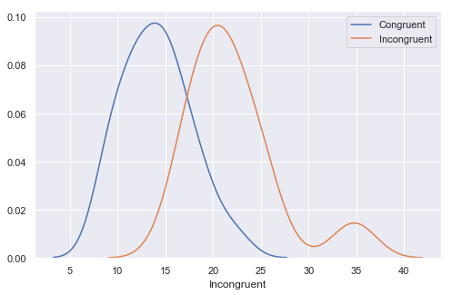

```python
#Distribution plot

sns.set(rc={'figure.figsize':(8, 5)})

dist_plot = sns.distplot(stroop_df['Congruent'], hist=False, label='Congruent')
dist_plot = sns.distplot(stroop_df['Incongruent'], hist=False, label='Incongruent')
```

> As you can see, both categories of data seem close to normally distributed. One thing to note is that the incongruent distribution seems to have outlier(s) skewing it's data slightly. Overall, the two distributions are close to one another, just the second data set is shifted to the right. This is an early indication that we may reject our null hypothesis in favor of our alternative.

## Statistical Test Results

> Confidence Level (CL) = **95%**

> Sample Size = **24**

> Degrees of Freedom (df) = **23**

> Given the CL, df and this being a two-tailed test  
> the critical statistic t-value = **2.07**

```python
# Finding the mean of the differences

stroop_df['Difference'] = stroop_df['Incongruent'] - stroop_df['Congruent']
mean_of_difference = stroop_df['Difference'].mean()
mean_of_difference
```

```
7.964791666666667
```

```python
# Taking the Standard Deviation of the two data sets and finding the difference

stroop_df['Difference'] = stroop_df['Congruent'] - stroop_df['Incongruent']
std_dev_of_difference = stroop_df['Difference'].std(axis=0)
std_dev_of_difference
```

```
4.864826910359056
```

Now we need to take the mean of the differences and divide by the Std Deviation of the difference divided by the square root of the sample size... in other words...

```python
# Calculation of t-statistic
# Taking the mean of the differences and dividing by the Std Deviation of the difference divided by the
# square root of the sample size

mean_of_difference/(std_dev_of_difference / math.sqrt(24))
```

```
8.020706944109957
```

The t-statistic we calculated is 8.02. This is larger than our critical t-statistic of 2.07.

## Therefore... We reject our null hypothesis in favor of our alternative.

> These findings line up with our initial thoughts and are not terribly surprising. We believed inititally that it would take longer to name the color of the ink each word is written in if the ink DOES NOT match the word. This likely has to do with how our brains process information. It seems we are quicker at identifying the color of a word before we have processed the word that is written.